# DSC5103 Assignment 3

Regularization Methods in Classification

Tong Wang

Sep 2018

## NOTE:

This assignment is **due at 23:59 of Oct 4, Thursday**. You can work on this file directly and fill in your answers/code below. Please submit the output HTML file (name your file like G1Group02.html if you are from Group 02 of Section G1) onto IVLE/Files/Student Submission/Assignment3 folder.

Also, put the Section/Group and member info below.

```r
# Section A1
# Group 13
# Members: REN JIEWEN, WANG XINRUI, XIAO RUI,LI LIPING
```

### Introduction

In this assignment, we will apply regularization methods (Ridge Regression, LASSO, and Elastic Net) to a classification problem, and compare them with traditional Logistic Regression.

Before we start, it is necessary to read through the documentation of the functions **glmnet()** (specifically, the *family* option), **cv.glmnet()** (the *family* and *type.measure* options), and **predict.glmnet()** (the *type* option) in the **glmnet** package, and find out how to run generalized linear models with regularization.

### Data Preparation

First, let us get the data. We will use the **Heart** data from the textbook, available at http://www-bcf.usc.edu/~gareth/ISL/Heart.csv.

```r
heart <- read.csv(file="http://www-bcf.usc.edu/~gareth/ISL/Heart.csv", row.names=1)
summary(heart)
```

```
##       Age             Sex                ChestPain       RestBP           Chol
##  Min.   :29.00   Min.   :0.0000   asymptomatic:144   Min.   : 94.0   Min.   :126.0
##  1st Qu.:48.00   1st Qu.:0.0000   nonanginal  : 86   1st Qu.:120.0   1st Qu.:211.0
##  Median :56.00   Median :1.0000   nontypical  : 50   Median :130.0   Median :241.0
##  Mean   :54.44   Mean   :0.6799   typical     : 23   Mean   :131.7   Mean   :246.7
##  3rd Qu.:61.00   3rd Qu.:1.0000                      3rd Qu.:140.0   3rd Qu.:275.0
##  Max.   :77.00   Max.   :1.0000                      Max.   :200.0   Max.   :564.0
##
##       Fbs            RestECG           MaxHR           ExAng           Oldpeak         Slope
##  Min.   :0.0000   Min.   :0.0000   Min.   : 71.0   Min.   :0.0000   Min.   :0.00   Min.   :1.000
##  1st Qu.:0.0000   1st Qu.:0.0000   1st Qu.:133.5   1st Qu.:0.0000   1st Qu.:0.00   1st Qu.:1.000
##  Median :0.0000   Median :1.0000   Median :153.0   Median :0.0000   Median :0.80   Median :2.000
##  Mean   :0.1485   Mean   :0.9901   Mean   :149.6   Mean   :0.3267   Mean   :1.04   Mean   :1.601
##  3rd Qu.:0.0000   3rd Qu.:2.0000   3rd Qu.:166.0   3rd Qu.:1.0000   3rd Qu.:1.60   3rd Qu.:2.000
##  Max.   :1.0000   Max.   :2.0000   Max.   :202.0   Max.   :1.0000   Max.   :6.20   Max.   :3.000
##
##        Ca                 Thal      AHD
##  Min.   :0.0000   fixed     : 18   No :164
##  1st Qu.:0.0000   normal    :166   Yes:139
##  Median :0.0000   reversable:117
##  Mean   :0.6722   NA's      :  2
##  3rd Qu.:1.0000
##  Max.   :3.0000
##  NA's   :4
```

The task is to use the features to predict **AHD**, binary outcome related to some heart disease.

Some cleaning is necessary because there are NA’s and also several categorical variables stored as numerical.

```r
# clean the NA's
heart <- na.omit(heart)
# convert to factors
heart$Sex <- as.factor(heart$Sex)
heart$Fbs <- as.factor(heart$Fbs)
heart$RestECG <- as.factor(heart$RestECG)
heart$ExAng <- as.factor(heart$ExAng)
heart$Slope <- as.factor(heart$Slope)
heart$Ca <- as.factor(heart$Ca)
summary(heart)
```

```
##       Age        Sex            ChestPain       RestBP           Chol       Fbs     RestECG
##  Min.   :29.00   0: 96   asymptomatic:142   Min.   : 94.0   Min.   :126.0   0:254   0:147
##  1st Qu.:48.00   1:201   nonanginal  : 83   1st Qu.:120.0   1st Qu.:211.0   1: 43   1:  4
##  Median :56.00           nontypical  : 49   Median :130.0   Median :243.0           2:146
##  Mean   :54.54           typical     : 23   Mean   :131.7   Mean   :247.4
##  3rd Qu.:61.00                              3rd Qu.:140.0   3rd Qu.:276.0
##  Max.   :77.00                              Max.   :200.0   Max.   :564.0
##      MaxHR       ExAng      Oldpeak      Slope   Ca              Thal      AHD
##  Min.   : 71.0   0:200   Min.   :0.000   1:139   0:174   fixed     : 18   No :160
##  1st Qu.:133.0   1: 97   1st Qu.:0.000   2:137   1: 65   normal    :164   Yes:137
##  Median :153.0           Median :0.800   3: 21   2: 38   reversable:115
##  Mean   :149.6           Mean   :1.056           3: 20
##  3rd Qu.:166.0           3rd Qu.:1.600
##  Max.   :202.0           Max.   :6.200
```

Next, we will prepare the training and test dataset for later model comparison.

```r
# split training and test data 50/50
N <- nrow(heart)
N.train <- round(N/2)
set.seed(456)
train.index <- sample(1:N, N.train)
data.train <- heart[train.index, ]
data.test <- heart[- train.index,]
```

### Questions and Answers

#### 1. [Logistic Regression as a benchmark] Find the optimal Logistic Regression model with **stepAIC()** using the training data, and use the model to predict using the test data. (1 Mark)

Answer:

```r
# put your R code here inside the blocks
model_glm <- glm(AHD~.,data = data.train,family = "binomial")
library(MASS)
step <- stepAIC(model_glm,trace=FALSE)
step$anova
```

```
## Stepwise Model Path
## Analysis of Deviance Table
##
## Initial Model:
## AHD ~ Age + Sex + ChestPain + RestBP + Chol + Fbs + RestECG +
##     MaxHR + ExAng + Oldpeak + Slope + Ca + Thal
##
## Final Model:
## AHD ~ Age + Sex + RestBP + MaxHR + ExAng + Slope + Ca + Thal
##
##
##          Step Df   Deviance Resid. Df Resid. Dev      AIC
## 1                                 127   73.68428 115.6843
## 2   - RestECG  2 0.12345231       129   73.80773 111.8077
## 3       - Fbs  1 0.08253164       130   73.89026 109.8903
## 4   - Oldpeak  1 0.35603100       131   74.24629 108.2463
## 5 - ChestPain  3 4.27620785       134   78.52250 106.5225
## 6      - Chol  1 1.79522895       135   80.31773 106.3177
```

```r
model_glm_optimal <- glm(AHD ~ Age + Sex + RestBP + MaxHR + ExAng + Slope + Ca + Thal,data=data.train,family = "binomial")
library(dplyr)
data.test_cut <- select(data.test,-AHD)
pred_glm <- predict(model_glm_optimal,newdata = data.test_cut,type = "response")
```

#### 2. [Ridge Regression] Fit a Ridge Regression model on the training data, use cross-validtion to find the optimal $\lambda$, and use the optimal model to predict on the test data. (1 Mark)

Answer:

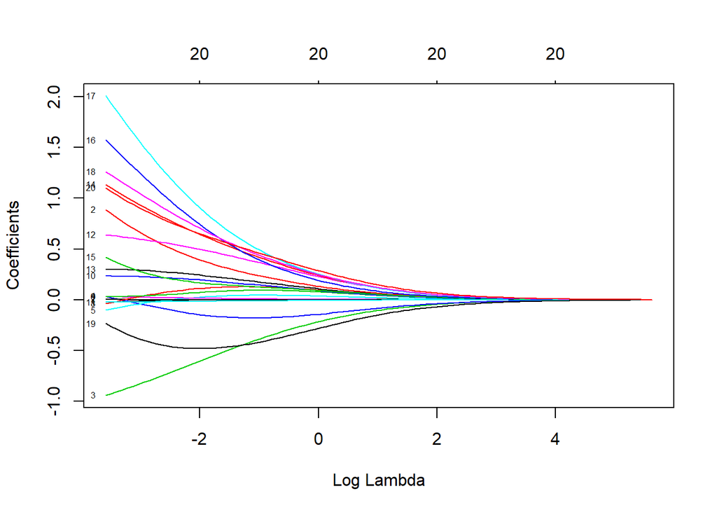

```r
# put your R code here inside the blocks
library("glmnetUtils")
ridge <- glmnet(AHD ~ ., data.train,family="binomial",alpha=0, use.model.frame=TRUE)
# plot the fitted model
plot(ridge, xvar="lambda", label=TRUE)
```

```r
## use CV to find optimal lambda
set.seed(1)
ridge.cv <- cv.glmnet(AHD~.,data.train,family="binomial",alpha=0,use.model.frame=TRUE)
plot(ridge.cv)
# optimal lambda
ridge.lam <- ridge.cv$lambda.min
log(ridge.lam)
```

```
## [1] -2.656182
```

```r
min(ridge.cv$cvm)
```

```
## [1] 0.8168807
```

```r
points(log(ridge.lam), min(ridge.cv$cvm), cex=3)
#### alternatively, set optimal lambda to lambda.1se for a more parsimonious model ####
ridge.lam2 <- ridge.cv$lambda.1se
log(ridge.lam2)
```

```
## [1] -0.7955071
```

```r
min(ridge.cv$cvm) + ridge.cv$cvsd[which.min(ridge.cv$cvm)]
```

```
## [1] 0.9098578
```

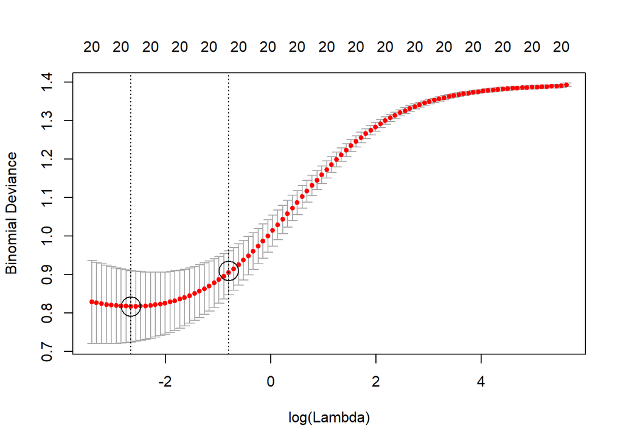

```r
points(log(ridge.lam2), min(ridge.cv$cvm) + ridge.cv$cvsd[which.min(ridge.cv$cvm)], cex=3)
```

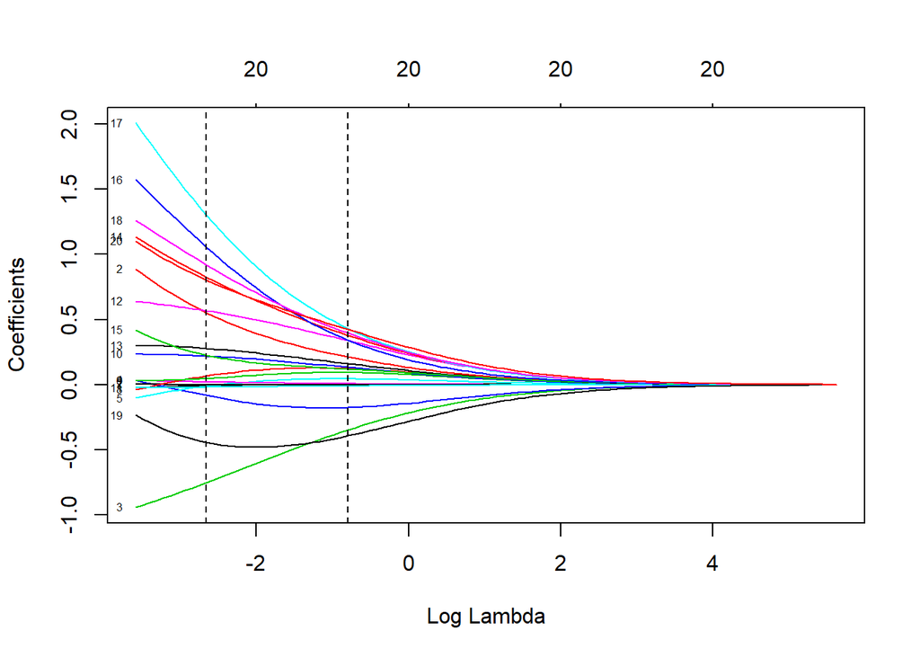

```r
# plot optimal lambda
plot(ridge.cv$glmnet.fit, xvar="lambda", label = TRUE)
abline(v=log(ridge.lam), lty=2)
abline(v=log(ridge.lam2), lty=2)
```

```r
#prediction using optimal lambda
pred_ridge <- predict(ridge.cv,s=ridge.lam2,newdata = data.test_cut, type="response",exact=TRUE)
```

#### 3. [LASSO] Fit a LASSO model on the training data, use cross-validtion to find the optimal $\lambda$, and use the optimal model to predict on the test data. (1 Mark)

Answer:

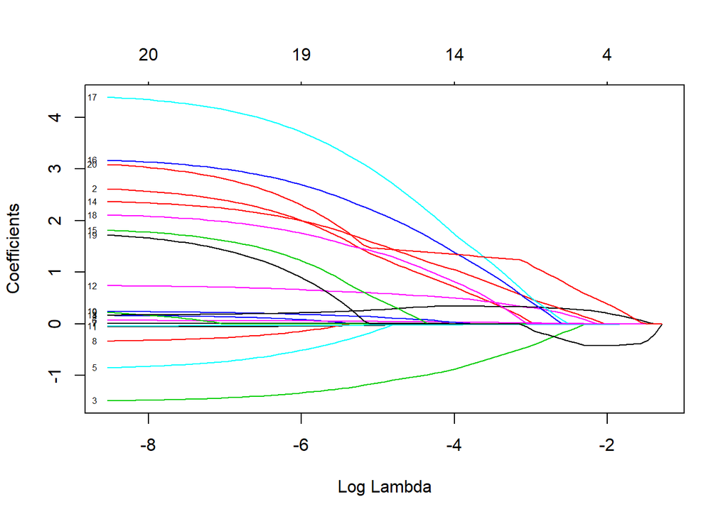

```r
# put your R code here inside the blocks
### The Lasso
# glmnet with alpha=1 means LASSO
lasso <- glmnet(AHD ~ .,data.train, family="binomial",alpha=1, use.model.frame=TRUE)
plot(lasso, xvar="lambda", label=TRUE)
```

```r
# CV for optimal lambda
set.seed(1)
lasso.cv <- cv.glmnet(AHD ~ .,data.train, family="binomial",alpha=1, use.model.frame=TRUE)
plot(lasso.cv)
# optimal lambda
lasso.lam <- lasso.cv$lambda.min
log(lasso.lam)
```

```
## [1] -3.981913
```

```r
points(log(lasso.lam), min(lasso.cv$cvm), cex=3)
#### alternatively, set optimal lambda to lambda.1se for a more parsimonious model ####
lasso.lam2 <- lasso.cv$lambda.1se
log(lasso.lam2)
```

```
## [1] -2.865508
```

```r
min(lasso.cv$cvm) + lasso.cv$cvsd[which.min(lasso.cv$cvm)]
```

```
## [1] 0.9352178
```

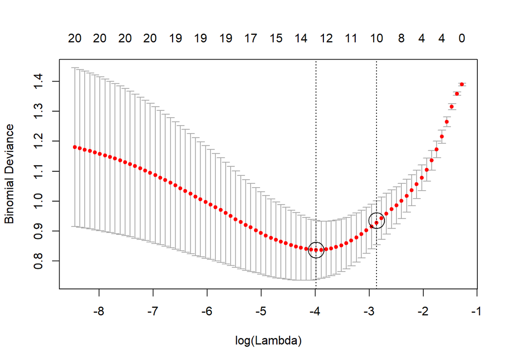

```r
points(log(lasso.lam2), min(lasso.cv$cvm) + lasso.cv$cvsd[which.min(lasso.cv$cvm)], cex=3)
```

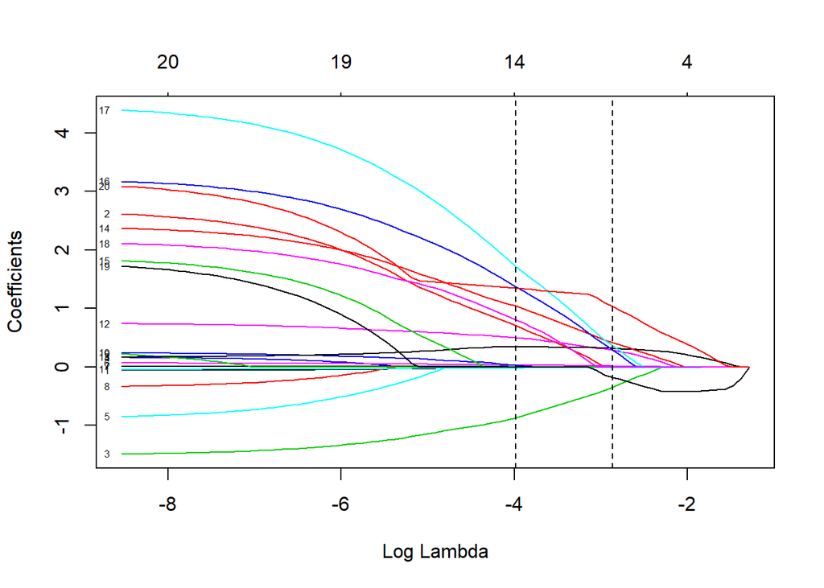

```r
# plot optimal lambda
plot(lasso.cv$glmnet.fit, xvar="lambda", label = TRUE)
abline(v=log(lasso.lam), lty=2)
abline(v=log(lasso.lam2), lty=2)
```

```r
# prediciton using optimal lambda
pred_lasso <- predict(lasso.cv, s=lasso.lam2, newdata=data.test_cut,type="response", exact=TRUE)
```

#### 4. [Elastic Net] Fit an Elastic Net model on the training data, use cross-validtion to find the optimal $\alpha$ and $\lambda$, and use the optimal model to predict on the test data. (1 Mark)

Answer:

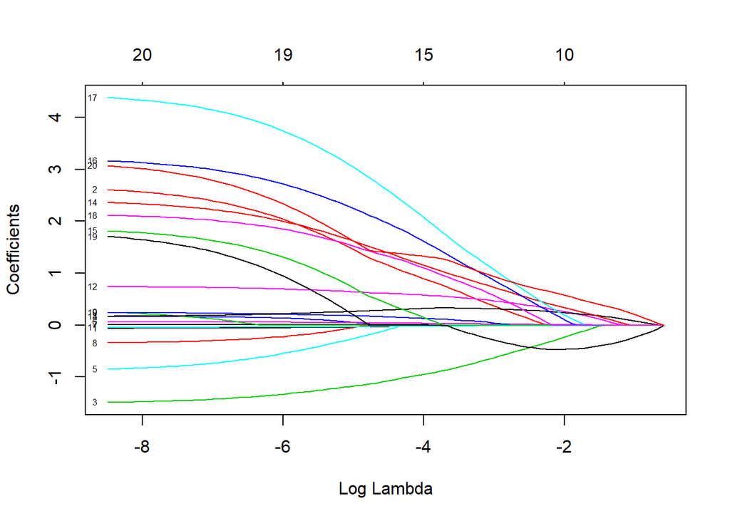

```r
# put your R code here inside the blocks
### The Elastic Net with a given alpha
# when 0 < alpha < 1, it becomes elastic net
en <- glmnet(AHD ~ ., data.train,family="binomial", alpha=0.5, use.model.frame=TRUE)
plot(en, xvar="lambda", label=TRUE)
```

```r
# CV
set.seed(1)
en.cv <- cv.glmnet(AHD ~ ., data.train,family="binomial", alpha=0.5, use.model.frame=TRUE)
plot(en.cv)
# optimal lambda
en.lam <- en.cv$lambda.min
log(en.lam)
```

```
## [1] -3.474833
```

```r
points(log(en.lam), min(en.cv$cvm), cex=3)
#### alternatively, set optimal lambda to lambda.1se for a more parsimonious model ####
en.lam2 <- en.cv$lambda.1se
log(en.lam2)
```

```
## [1] -2.265394
```

```r
min(en.cv$cvm) + en.cv$cvsd[which.min(en.cv$cvm)]
```

```
## [1] 0.9150633
```

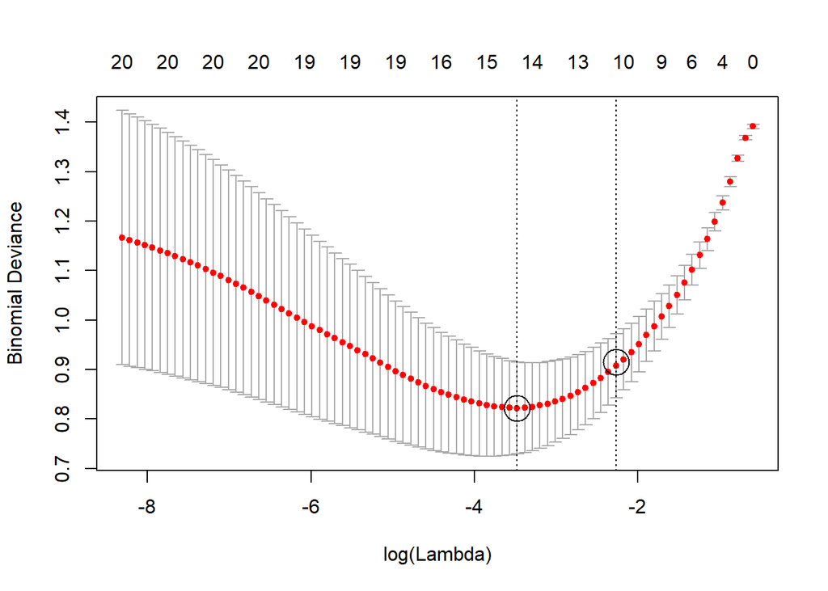

```r
points(log(en.lam2), min(en.cv$cvm) + en.cv$cvsd[which.min(en.cv$cvm)], cex=3)
```

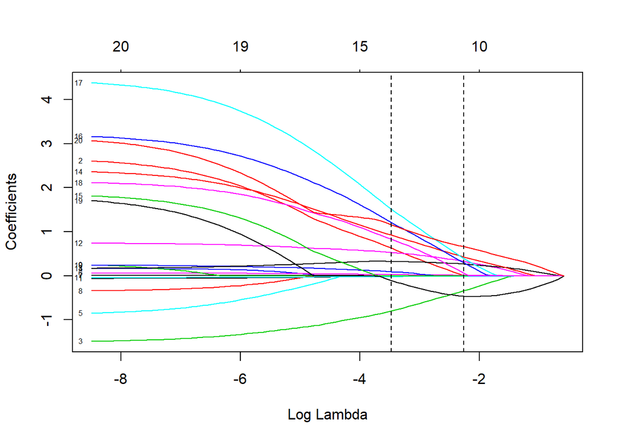

```r
# plot optimal lambda
plot(en.cv$glmnet.fit, xvar="lambda", label = TRUE)
abline(v=log(en.lam), lty=2)
abline(v=log(en.lam2), lty=2)
```

```r
# prediciton using optimal lambda
pred_en <- predict(en.cv, s=en.lam2, newdata=data.test_cut,type="response", exact=TRUE)
```

#### 5. Compare the above-studied model predictions in terms of misclassification rate, ROC, and AUC. (1 Mark)

Answer:

```r
# put your R code here inside the blocks
library(ROCR)
```

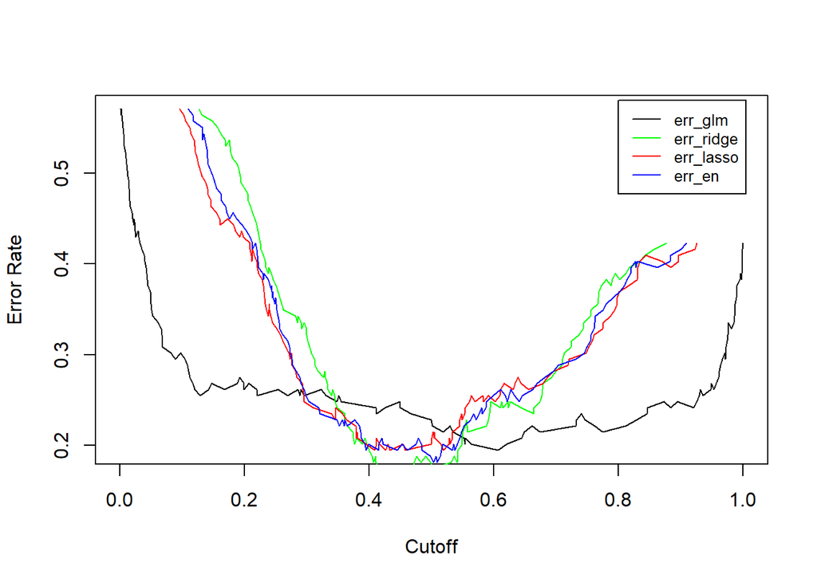

```r
pred.glm <- prediction(pred_glm,data.test$AHD)
pred.ridge <- prediction(pred_ridge,data.test$AHD)
pred.lasso <- prediction(pred_lasso,data.test$AHD)
pred.en <- prediction(pred_en,data.test$AHD)
#misclassification rate
err_glm <- performance(pred.glm,"err")
err_ridge <- performance(pred.ridge,"err")
err_lasso <- performance(pred.lasso,"err")
err_en <- performance(pred.en,"err")
#plot error
plot(err_glm,col="black")
plot(err_ridge,col="green",add=TRUE)
plot(err_lasso,col="red",add=TRUE)
plot(err_en,col="blue",add=TRUE)
legend(x=0.8,y=0.58,legend = c("err_glm","err_ridge","err_lasso","err_en"),lty = c(1,1,1,1),lwd = c(1,1,1,1),col = c("black","green","red","blue"),cex=0.8)
```

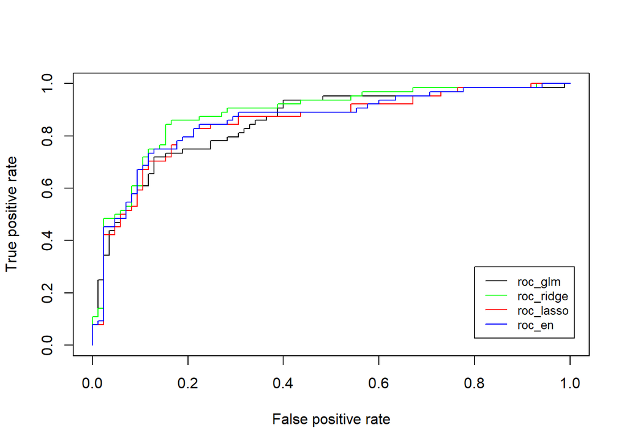

```r
#roc
roc_glm <- performance(pred.glm,"tpr","fpr")
roc_ridge <- performance(pred.ridge,"tpr","fpr")
roc_lasso <- performance(pred.lasso,"tpr","fpr")
roc_en <- performance(pred.en,"tpr","fpr")
#plot roc
plot(roc_glm,col="black")
plot(roc_ridge,col="green",add=TRUE)
plot(roc_lasso,col="red",add=TRUE)
plot(roc_en,col="blue",add=TRUE)
legend(x=0.8,y=0.3,legend = c("roc_glm","roc_ridge","roc_lasso","roc_en"),lty = c(1,1,1,1),lwd = c(1,1,1,1),col = c("black","green","red","blue"),cex=0.8)
```

```r
#auc
performance(pred.glm,"auc")@y.values[[1]]
```

```
## [1] 0.853125
```

```r
performance(pred.ridge,"auc")@y.values[[1]]
```

```
## [1] 0.8830882
```

```r
performance(pred.lasso,"auc")@y.values[[1]]
```

```
## [1] 0.8492647
```

```r
performance(pred.en,"auc")@y.values[[1]]
```

```
## [1] 0.8577206
```